# Homework 7 Predictive analytics

Salma Elshahawy

2021-04-18

[Github repo](https://github.com/salma71/MSDS_spring2021/tree/master/data_624) | [portfolio](https://salma71.github.io/) | [Blog](https://salmaeng71.medium.com/)

## Problem 6.2

Developing a model to predict permeability (see Sect. 1.4) could save significant resources for a pharmaceutical company, while at the same time more rapidly identifying molecules that have a sufficient permeability to become a drug:

1. Start R and use these commands to load the data

The matrix `fingerprints` contains the 1,107 binary molecular predictors for the 165 compounds, while permeability contains permeability response.

2. The fingerprint predictors indicate the presence or absence of substructures of a molecule and are often sparse meaning that relatively few of the molecules contain each substructure. Filter out the predictors that have low frequencies using the nearZeroVar function from the caret package. How many predictors are left for modeling?

```
#> [1] "719 columns are removed. 388 columns are left for modeling."
```

3. Split the data into a training and a test set, pre-process the data, and tune a PLS model. How many latent variables are optimal and what is the corresponding resampled estimate of R^2?

Below, the data is splitted into train/test set, using the createDataPartition function.

I used the train function to perform the pre-process and tuning together. The function first preprocess the training set by centering it and scaling it. Then the function uses 10-fold cross validation to try the ncomp parameter (number of components, i.e. latent variables) of the PLS model from 1 to 20.

```
#> Partial Least Squares
#>
#> 133 samples
#> 388 predictors
#>
#> Pre-processing: centered (388), scaled (388)
#> Resampling: Cross-Validated (10 fold)
#> Summary of sample sizes: 120, 120, 120, 119, 120, 119, ...
#> Resampling results across tuning parameters:
#>
#>   ncomp  RMSE      Rsquared   MAE
#>    1     12.66375  0.3461521  9.603300
#>    2     11.66557  0.4884962  8.364131
#>    3     11.86090  0.4462082  9.081715
#>    4     12.15438  0.4254096  9.389547
#>    5     12.00549  0.4492658  9.076973
#>    6     11.70875  0.4618761  8.826006
#>    7     11.42799  0.4775314  8.747634
#>    8     11.25481  0.4925856  8.533191
#>    9     11.03884  0.5066896  8.344461
#>   10     10.88506  0.5187689  8.028416
#>   11     10.80216  0.5271005  8.012505
#>   12     10.81509  0.5247495  8.034195
#>   13     10.74326  0.5245241  8.003891
#>   14     10.70988  0.5238880  7.892343
#>   15     10.87078  0.5198265  8.032440
#>   16     11.25383  0.4999003  8.375209
#>   17     11.52949  0.4886010  8.619614
#>   18     11.46969  0.4907743  8.541789
#>   19     11.46414  0.4906053  8.591222
#>   20     11.38025  0.5003197  8.484932
#>
#> Rsquared was used to select the optimal model using the largest value.
#> The final value used for the model was ncomp = 11.
```

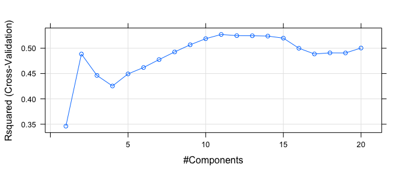

4. Predict the response for the test set. What is the test set estimate of R^2?

The postResample function from the caret package can be use to find the R^2 in the test set, using the selected model.

```
#>       RMSE   Rsquared        MAE
#> 15.4341377  0.2899935 11.6639869
```

5. Try building other models discussed in this chapter. Do any have better predictive performance?

I will utilize the following types:

1. Ridge regression, parameter tuned: lambda (from 0 to 1 by 0.1)
2. Lasso, parameter tuned: fraction (from 0 to 0.5 by 0.05)
3. Elastic net, parameters tuned: fraction and lambda (2-D grid with each D from 0 to 1 by 0.1)

I ensure that all of the models have the same seed, so their CV sets are identical. This way, I can then use the resamples functions to compare all 4 models at once. The R^2 metrics are used in all cases.

```
#> Ridge Regression
#>
#> 133 samples
#> 388 predictors
#>
#> Pre-processing: centered (388), scaled (388)
#> Resampling: Cross-Validated (10 fold)
#> Summary of sample sizes: 120, 120, 120, 119, 120, 119, ...
#> Resampling results across tuning parameters:
#>
#>   lambda  RMSE      Rsquared   MAE
#>   0.0     12.31893  0.4528045   9.294510
#>   0.1     10.79390  0.5292391   7.935830
#>   0.2     11.15821  0.5289694   8.241192
#>   0.3     11.56911  0.5286210   8.612171
#>   0.4     12.09487  0.5259461   9.039822
#>   0.5     12.67474  0.5230682   9.494363
#>   0.6     13.29786  0.5205254  10.029131
#>   0.7     13.95945  0.5179546  10.622090
#>   0.8     14.64851  0.5156990  11.217376
#>   0.9     15.36147  0.5136360  11.828589
#>   1.0     16.09410  0.5117506  12.434283
#>
#> Rsquared was used to select the optimal model using the largest value.
#> The final value used for the model was lambda = 0.1.
```

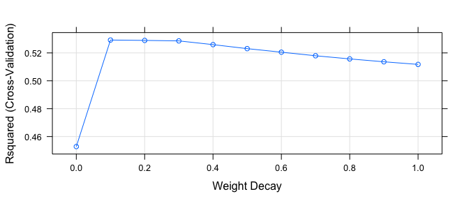

```
#> The lasso
#>
#> 133 samples
#> 388 predictors
#>
#> Pre-processing: centered (388), scaled (388)
#> Resampling: Cross-Validated (10 fold)
#> Summary of sample sizes: 120, 120, 120, 119, 120, 119, ...
#> Resampling results across tuning parameters:
#>
#>   fraction  RMSE      Rsquared   MAE
#>   0.00      14.62719        NaN  11.901845
#>   0.05      13.29247  0.4552939  10.359126
#>   0.10      12.80621  0.4554363   9.552588
#>   0.15      12.90315  0.4235837   9.618665
#>   0.20      12.87604  0.4068843   9.600865
#>   0.25      12.75649  0.4114738   9.556420
#>   0.30      12.66593  0.4169995   9.558130
#>   0.35      12.58089  0.4227670   9.518502
#>   0.40      12.50366  0.4283152   9.458058
#>   0.45      12.44435  0.4366066   9.404528
#>   0.50      12.35249  0.4422982   9.333097
#>
#> Rsquared was used to select the optimal model using the largest value.
#> The final value used for the model was fraction = 0.1.
```

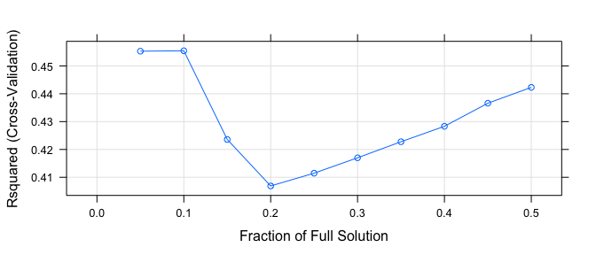

```
#> Elasticnet
#>
#> 133 samples
#> 388 predictors
#>
#> Pre-processing: centered (388), scaled (388)
#> Resampling: Cross-Validated (10 fold)
#> Summary of sample sizes: 120, 120, 120, 119, 120, 119, ...
#> Resampling results across tuning parameters:
#>
#>   lambda  fraction  RMSE      Rsquared   MAE
#>   0.0     0.0       14.62719        NaN  11.901845
#>   0.0     0.1       12.80621  0.4554363   9.552588
#>   0.0     0.2       12.87604  0.4068843   9.600865
#>   0.0     0.3       12.66593  0.4169995   9.558130
#>   0.0     0.4       12.50366  0.4283152   9.458058
#>   0.0     0.5       12.35249  0.4422982   9.333097
#>   0.0     0.6       12.25156  0.4459605   9.303113
#>   0.0     0.7       12.19984  0.4489988   9.311995
#>   0.0     0.8       12.21014  0.4503081   9.280251
#>   0.0     0.9       12.24057  0.4526927   9.271295
#>   0.0     1.0       12.31893  0.4528045   9.294510
#>   0.1     0.0       15.17471        NaN  12.242520
#>   0.1     0.1       11.55434  0.4874903   8.229407
#>   0.1     0.2       11.63397  0.4714981   8.459077
#>   0.1     0.3       11.17731  0.5023828   8.228974
#>   0.1     0.4       10.93531  0.5152918   8.045882
#>   0.1     0.5       10.80908  0.5216687   7.920525
#>   0.1     0.6       10.72893  0.5273809   7.828944
#>   0.1     0.7       10.69309  0.5308887   7.777732
#>   0.1     0.8       10.72480  0.5308325   7.832275
#>   0.1     0.9       10.75986  0.5298811   7.908604
#>   0.1     1.0       10.79390  0.5292391   7.935830
#>   0.2     0.0       15.17471        NaN  12.242520
#>   0.2     0.1       11.48301  0.4945241   8.170117
#>   0.2     0.2       11.84209  0.4696152   8.505668
#>   0.2     0.3       11.43389  0.4958256   8.375297
#>   0.2     0.4       11.19698  0.5114505   8.243848
#>   0.2     0.5       11.09985  0.5182971   8.147914
#>   0.2     0.6       11.00732  0.5263811   8.075977
```

[output cut: 80 more lines]

```
#>   0.9     1.0       15.36147  0.5136360  11.828589
#>   1.0     0.0       15.17471        NaN  12.242520
#>   1.0     0.1       11.60369  0.4838849   7.823994
#>   1.0     0.2       13.24717  0.4844231   8.565415
#>   1.0     0.3       14.49421  0.4757489  10.001137
#>   1.0     0.4       14.95867  0.4828266  10.733226
#>   1.0     0.5       15.22359  0.4895516  11.135659
#>   1.0     0.6       15.42999  0.4952250  11.523292
#>   1.0     0.7       15.58606  0.5014637  11.753596
#>   1.0     0.8       15.75800  0.5060329  11.990365
#>   1.0     0.9       15.91616  0.5098193  12.235461
#>   1.0     1.0       16.09410  0.5117506  12.434283
#>
#> Rsquared was used to select the optimal model using the largest value.
#> The final values used for the model were fraction = 0.7 and lambda = 0.1.
```

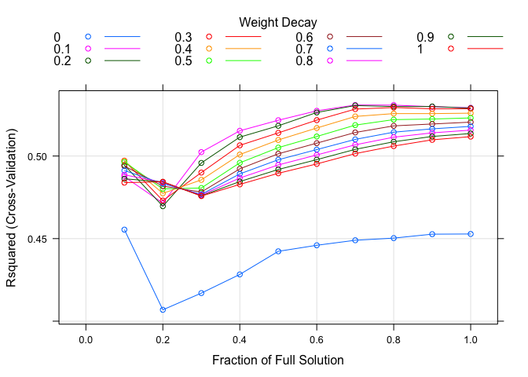

```
#>
#> Call:
#> summary.resamples(object = resamp)
#>
#> Models: PLS, Ridge, Lasso, enet
#> Number of resamples: 10
#>
#> MAE
#>           Min.  1st Qu.   Median     Mean  3rd Qu.     Max. NA's
#> PLS   3.431086 6.279454 8.683473 8.012505 9.946990 10.48475    0
#> Ridge 2.932725 6.407812 8.665880 7.935830 9.924056 10.45745    0
#> Lasso 5.791257 7.693374 7.903535 9.552588 9.632303 21.21770    1
#> enet  2.993593 6.181506 8.157837 7.777732 9.796487 10.79813    0
#>
#> RMSE
#>           Min.  1st Qu.   Median     Mean  3rd Qu.     Max. NA's
#> PLS   4.127860 7.883648 12.72946 10.80216 13.06351 14.98578    0
#> Ridge 3.517458 8.293763 12.22699 10.79390 13.11415 15.70450    0
#> Lasso 7.657579 8.839116 12.01826 12.80621 14.38416 25.37189    1
#> enet  3.616262 8.054933 11.81838 10.69309 13.31569 14.94121    0
#>
#> Rsquared
#>               Min.   1st Qu.    Median      Mean   3rd Qu.      Max. NA's
#> PLS   0.0007971331 0.3795375 0.5019221 0.5271005 0.7601007 0.9084493    0
#> Ridge 0.0047218766 0.3487174 0.5283737 0.5292391 0.7709032 0.9297472    0
#> Lasso 0.0235890619 0.1246479 0.5805556 0.4554363 0.7421118 0.8656899    1
#> enet  0.0042021862 0.3407759 0.5243361 0.5308887 0.7766468 0.9259750    0
```

Below, I also evaluate the models using the test set:

```
#>       RMSE   Rsquared        MAE
#> 15.4341377  0.2899935 11.6639869
```

```
#> $pls
#>       RMSE   Rsquared        MAE
#> 15.4341377  0.2899935 11.6639869
#>
#> $ridge
#>       RMSE   Rsquared        MAE
#> 15.0822363  0.3047575 11.4460367
#>
#> $lasso
#>       RMSE   Rsquared        MAE
#> 12.3663838  0.3954258  9.1764050
#>
#> $enet
#>       RMSE   Rsquared        MAE
#> 14.1795387  0.3415212 10.7570758
```

Nonetheless, the scores for the Ridge, Lasso, and Enet are all higher (better performance) than the PLS.

6. Would you recommend any of your models to replace the permeability laboratory experiment?

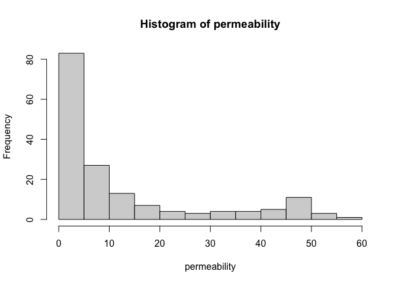

We can see that most of permeability are under 10. The model’s accuracy is not good enough to replace lab test.

## Problem 6.3

A chemical manufacturing process for a pharmaceutical product was discussed in Sect. 1.4. In this problem, the objective is to understand the relationship between biological measurements of the raw materials (predictors), measurements of the manufacturing process (predictors), and the response of product yield. Biological predictors cannot be changed but can be used to assess the quality of the raw material before processing. On the other hand, manufacturing process predictors can be changed in the manufacturing process. Improving product yield by 1% will boost revenue by approximately one hundred thousand dollars per batch:

1. Start R and use these commands to load the data.

The matrix processPredictors contains the 57 predictors (12 describing the input biological material and 45 describing the process predictors) for the 176 manufacturing runs. yield contains the percent yield for each run.

2. A small percentage of cells in the predictor set contain missing values. Use an imputation function to fill in these missing values (e.g., see Sect. 3.8).

The preProcess function can be used to impute the imssing value. I choose to use the ‘bagImpute’ method, which impute the missing values through bagged tree model.

```
#> Created from 152 samples and 57 variables
#>
#> Pre-processing:
#>   - bagged tree imputation (57)
#>   - ignored (0)
```

3. Split the data into a training and a test set, pre-process the data, and tune a model of your choice from this chapter. What is the optimal value of the performance metric?

The elastic net model is tuned using 10-fold cross validation with parameters lambda ranging from 0 to 1, and fraction ranging from 0 to 1. The metric used to decide is the RMSE.

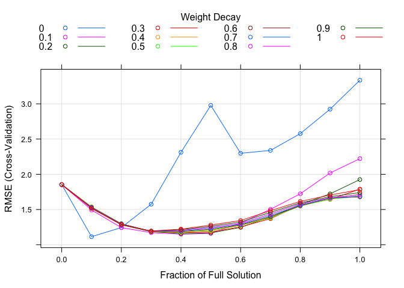

4. Predict the response for the test set. What is the value of the performance metric and how does this compare with the resampled performance metric on the training set?

```
#>      RMSE  Rsquared       MAE
#> 1.0611572 0.6019381 0.8536509
```

5. Which predictors are most important in the model you have trained? Do either the biological or process predictors dominate the list?

The coefficients of the best-tuned elastic net model is below. We can see that the elastic net zero out some of the predictors, due to the lasso penalty.

```
#>   BiologicalMaterial01   BiologicalMaterial02   BiologicalMaterial03
#>             0.00000000             0.00000000             0.00000000
#>   BiologicalMaterial04   BiologicalMaterial05   BiologicalMaterial06
#>             0.00000000             0.00000000             0.08872051
#>   BiologicalMaterial07   BiologicalMaterial08   BiologicalMaterial09
#>             0.00000000             0.00000000             0.00000000
#>   BiologicalMaterial10   BiologicalMaterial11   BiologicalMaterial12
#>             0.00000000             0.00000000             0.00000000
#> ManufacturingProcess01 ManufacturingProcess02 ManufacturingProcess03
#>             0.00000000             0.00000000             0.00000000
#> ManufacturingProcess04 ManufacturingProcess05 ManufacturingProcess06
#>             0.04275827             0.00000000             0.04748137
#> ManufacturingProcess07 ManufacturingProcess08 ManufacturingProcess09
#>            -0.04828912             0.00000000             0.45351080
#> ManufacturingProcess10 ManufacturingProcess11 ManufacturingProcess12
#>             0.00000000             0.00000000             0.00000000
#> ManufacturingProcess13 ManufacturingProcess14 ManufacturingProcess15
#>            -0.21934545             0.00000000             0.06315242
#> ManufacturingProcess16 ManufacturingProcess17 ManufacturingProcess18
#>             0.00000000            -0.22082836             0.00000000
#> ManufacturingProcess19 ManufacturingProcess20 ManufacturingProcess22
#>             0.00000000             0.00000000             0.00000000
#> ManufacturingProcess23 ManufacturingProcess24 ManufacturingProcess25
#>             0.00000000             0.00000000             0.00000000
#> ManufacturingProcess26 ManufacturingProcess27 ManufacturingProcess28
#>             0.00000000             0.00000000             0.00000000
#> ManufacturingProcess29 ManufacturingProcess30 ManufacturingProcess31
#>             0.00000000             0.00000000             0.00000000
#> ManufacturingProcess32 ManufacturingProcess33 ManufacturingProcess34
#>             0.80779340             0.00000000             0.12023091
#> ManufacturingProcess35 ManufacturingProcess36 ManufacturingProcess37
#>             0.00000000            -0.19025738            -0.12077693
#> ManufacturingProcess38 ManufacturingProcess39 ManufacturingProcess40
#>             0.00000000             0.10800365             0.00000000
#> ManufacturingProcess41 ManufacturingProcess42 ManufacturingProcess43
#>             0.00000000             0.02043653             0.00000000
#> ManufacturingProcess44 ManufacturingProcess45
#>             0.00000000             0.05192492
```

We can compare the non-zero coefficients by taking their absolute value, and then sorting them:

```
#> ManufacturingProcess32 ManufacturingProcess09 ManufacturingProcess17
#>             0.80779340             0.45351080             0.22082836
#> ManufacturingProcess13 ManufacturingProcess36 ManufacturingProcess37
#>             0.21934545             0.19025738             0.12077693
#> ManufacturingProcess34 ManufacturingProcess39   BiologicalMaterial06
#>             0.12023091             0.10800365             0.08872051
#> ManufacturingProcess15 ManufacturingProcess45 ManufacturingProcess07
#>             0.06315242             0.05192492             0.04828912
#> ManufacturingProcess06 ManufacturingProcess04 ManufacturingProcess42
#>             0.04748137             0.04275827             0.02043653
```

We can conclude the following:

```
#> loess r-squared variable importance
#>
#>   only 20 most important variables shown (out of 57)
#>
#>                        Overall
#> ManufacturingProcess32  100.00
#> ManufacturingProcess13   82.21
#> ManufacturingProcess36   79.47
#> BiologicalMaterial06     75.61
#> BiologicalMaterial03     71.87
#> ManufacturingProcess17   70.62
#> BiologicalMaterial12     66.86
#> ManufacturingProcess09   62.20
#> ManufacturingProcess06   55.45
#> BiologicalMaterial02     53.61
#> ManufacturingProcess31   46.70
#> ManufacturingProcess33   45.66
#> BiologicalMaterial11     42.39
#> BiologicalMaterial04     39.70
#> ManufacturingProcess29   36.88
#> ManufacturingProcess11   36.39
#> ManufacturingProcess12   35.50
#> BiologicalMaterial08     31.86
#> BiologicalMaterial09     30.98
#> BiologicalMaterial01     29.67
```

Again, 11 out of the 20 in the list are ManufacturingProcess predictors, which makes it more important than BiologicalMaterial.

6. Explore the relationships between each of the top predictors and the response. How could this information be helpful in improving yield in future runs of the manufacturing process?

Elastic net is a linear regression model. The coefficients directly explain how the predictors affect the target. Positive coefficients improve the yield, while negative coefficients decrease the yield.

For the ManufacturingProcess having the positive coefficients, I would alter the process such that the predictor value increases. Below are the ManufacturingProcess having positive coefficients:

```
#> ManufacturingProcess32 ManufacturingProcess09 ManufacturingProcess34
#>             0.80779340             0.45351080             0.12023091
#> ManufacturingProcess39 ManufacturingProcess15 ManufacturingProcess45
#>             0.10800365             0.06315242             0.05192492
#> ManufacturingProcess06 ManufacturingProcess04 ManufacturingProcess42
#>             0.04748137             0.04275827             0.02043653
```

For the ManufacturingProcess having the negative coefficients, I would alter the process such that the predictor value decreases. Below are the ManufacturingProcess having negative coefficients:

```
#> ManufacturingProcess17 ManufacturingProcess13 ManufacturingProcess36
#>            -0.22082836            -0.21934545            -0.19025738
#> ManufacturingProcess37 ManufacturingProcess07
#>            -0.12077693            -0.04828912
```